# Project Setup

Before creating the ship’s template, we’ll start by setting up our project settings.

We’ll do it all at once to not have to go back to the *Project Settings* window later.

In this lesson, we will:

1. Give our game a nice background color.
2. Change the default physics settings.
3. Name our game’s physics layers.
4. Change the game’s base resolution.
5. And populate the input map.

Start by creating a copy of the starter project and import it in Godot.

You can find it in the course downloads, in the `godot-projects/tactical-space-combat/start-project/` directory.

## Changing the background color

First, we’ll change the game’s background color, also called *clear color*.

Head to *Project -> Project Settings… -> General -> Rendering -> Environment* and click the color rectangle next to *Default Clear Color*.

With the add-on that ships with the project, you’ll see a palette below the regular color picker. You can click any swatch to use it.

Since we’re making a space game, I chose the darkest color from the palette: `#272736`.

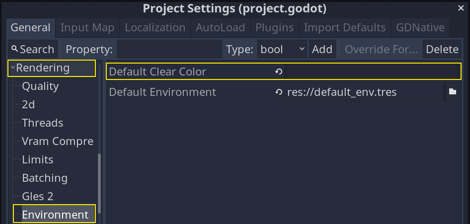

## Changing the default physics properties

In this project, for our weapons’ projectiles, we’ll use the

[figure not shown]

`RigidBody2D` node. It allows us to move projectiles in a straight line with almost no code.

However, by default, rigid bodies fall due to the default gravity. Thankfully, we can disable them and avoid having to reset them on every node.

In the *Physics -> 2d* category, set the following properties to `0`:

- *Default Gravity*.
- *Default Linear Damp*.
- *Default Angular Damp*.

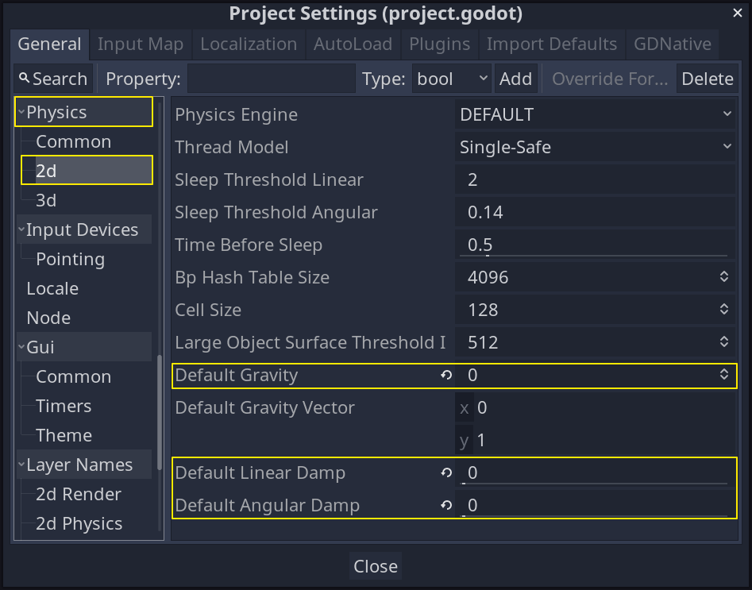

## Naming the physics layers

To track physics interactions easily, it’s always a good practice to name physics layers. Otherwise, they’re just numbers.

Head to the *Layer Names -> 2d Physics* category and name the layers as follows:

- *Layer 1*: `Ships`
- *Layer 2*: `ShipPlayer`
- *Layer 3*: `ShipAI`
- *Layer 20*: `UI`

I chose to set *Layer 20* to `UI` instead of *Layer 4* to distinguish it from the rest in the *Inspector*.

Certain elements interact with each other in the ship.

For example, the rooms detect units walking in or out, and doors. They find and store the position of their entrace and exit. We use *Layer 1* for this: `Ships`.

We also have elements that don’t need to interact with each other on the same ship.

Instead they interact with the enemy ship. One example would be the weapons.

For these, we have *Layer 2*, `ShipPlayer`, and *Layer 3*, `ShipAI`.

Lastly, we have elements that interact with the player.

For example, we can select units in the ship by dragging a selection box. For these elements we reserve *Layer 20*, `UI`.

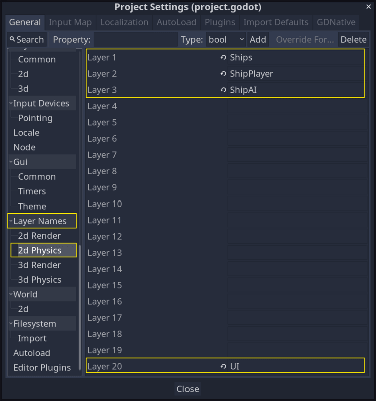

## The display settings

Lastly, we want to set our game’s base resolution. It’s good to change it early on as the placement of sprites depends on it.

Head to *Display -> Window* and change the following properties:

- *Width*: `1920`
- *Height*: `1080`
- *Fullscreen*: `true`

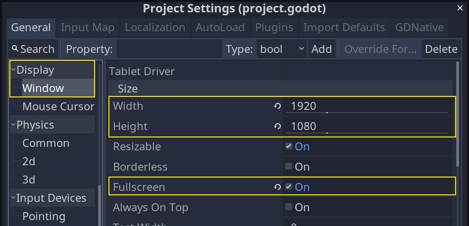

I turned on *Fullscreen* by default since the HD resolution would take up all or most of the display. If you prefer, you can set a smaller test resolution and keep the game windowed by default.

## The input map

We’ll wrap up with mouse bindings.

Because we’ll primarily use the mouse to interact with the game, we add the following two input actions to the *Input Map* tab:

1. `left_click` maps to the left mouse button.
2. `right_click` maps to the right mouse button.

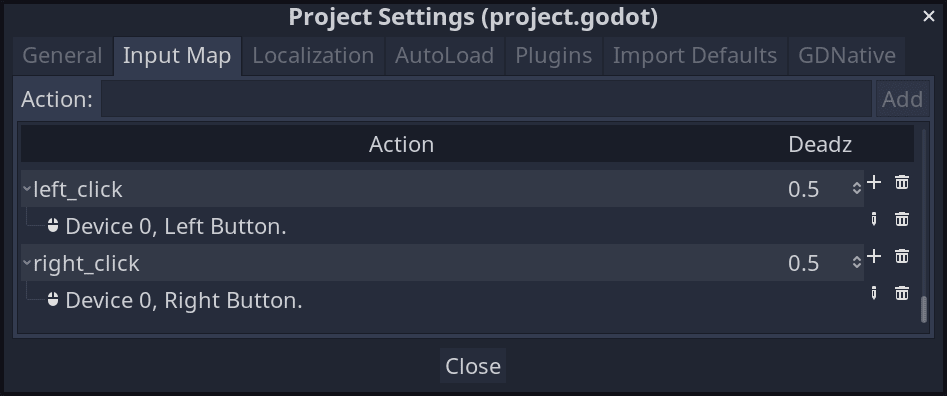

## A useful global script

Before moving on, here’s a trick to programmatically get your physics layers as an enum. This allows you to access them as constants throughout your codebase without hard-coding them.

Create a new script called `Global.gd`, which we’ll register as an *Autoload* for global access. You can save it at the project’s root.

It should have the following code:

```
extends Node

## Provides easy access to physics layers and masks from code.
enum Layers { NONE }


func _ready() -> void:
    var label := 'layer_names/2d_physics/layer_%d'
    # We loop over the index of each layer and try to get its name. If it has a
    # name, we add it to our `Layers` enum.
    for i in range(20):
        var layer_name: String = ProjectSettings.get_setting(label % (i + 1))
        if layer_name != '':
            # We call `<<` the left-shift bit-wise operator. It shifts the
            # bits to the left by adding zeros to the right hand side.
            # So `1 << 3 == 0b1000` which in decimals means 8. The `0b` prefix
            # instructs Godot that this is a binary value.
            #
            # 1 << 1 == 2
            # 1 << 3 == 8
            #
            # Thus, `1 << x` is the same as `2 to the power of x`.
            Layers[layer_name.to_upper()] = 1 << i
```

Now that we have `Global.gd`, add it as a singleton script by going to *Project -> Project Settings… -> Autoload*.

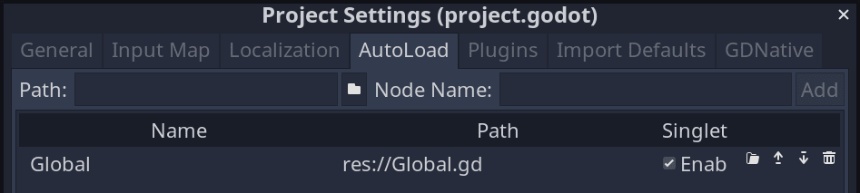

### How we programmatically populate our enum

In Godot, the enum data type uses a dictionary under the hood. This means we have access to the same dictionary API in GDScript for enums. This means we can manipulate enum values at run-time **as if they were** dictionaries.

In `Global.gd` we use `ProjectSettings` API to extend the `Layers` enum which ends up holding these values: `{NONE: 0, SHIPS: 1, SHIPAI:4, SHIPPLAYER: 2, UI: 524288}`.

We do this to keep our global settings in sync with our code values instead of manually hard-coding them.

We use the bit-wise left-shift operator (`<<`) because Godot stores layers as bit values. Manipulating these values with the bit-wise left-shift operator is easier for our purposes.

This is a common way to handle flags that can hold more than two values. We generally use a `bool` to represent one on or off state, but for flags with more than one state, bits are handy.

### More on binary numbers

For example, `0b000` is a binary number of three digits (the digits after `0b`). This means that we have three boolean flags to work with.

Each flag could be on or off individually. `0b111` means they’re all set to *on*, while `0b001` means that the first flag is on (we read them from right-to-left).

These bit values correspond to `7` and respectively `1` in decimal. The `0b` prefix instructs Godot that this is a binary value, so `0b001` is valid but `0b002` is not.

## Code reference

`Global.gd`:

```
extends Node


enum Layers { NONE }


func _ready() -> void:
    var label := 'layer_names/2d_physics/layer_%d'
    for i in range(20):
        var layer_name: String = ProjectSettings.get_setting(label % (i + 1))
        if layer_name != '':
            Layers[layer_name.to_upper()] = 1 << i
```